# Abundances

Thomas Amble Karlsen

2026-02-12

## 1 Loading libraries

```r
library(tidyverse) # general usage (wrangling, plotting...)
library(phyloseq) # exploring the microbiome and importing into R from Kraken-BIOM
library(microViz) # visualization of microbiome data
library(patchwork) # plotting
```

## 2 Loading data

```r
readRDS("/Users/thomasamble/Downloads/Master/R_master/rds/phyloseq.rds") %>%
  list2env(envir = .GlobalEnv)
```

## 3 Control samples

Creating a barplot of the top 12 species for the two control samples. Also creating tables of the top 10 most abundant species in the Microbiota control sample. Finally creating a table of the relative abundances of the 10 species present in the *ZymoBIOMICS Microbial Community Standard* for the Microbiota control sample, alongside the expected relative abundances of these species.

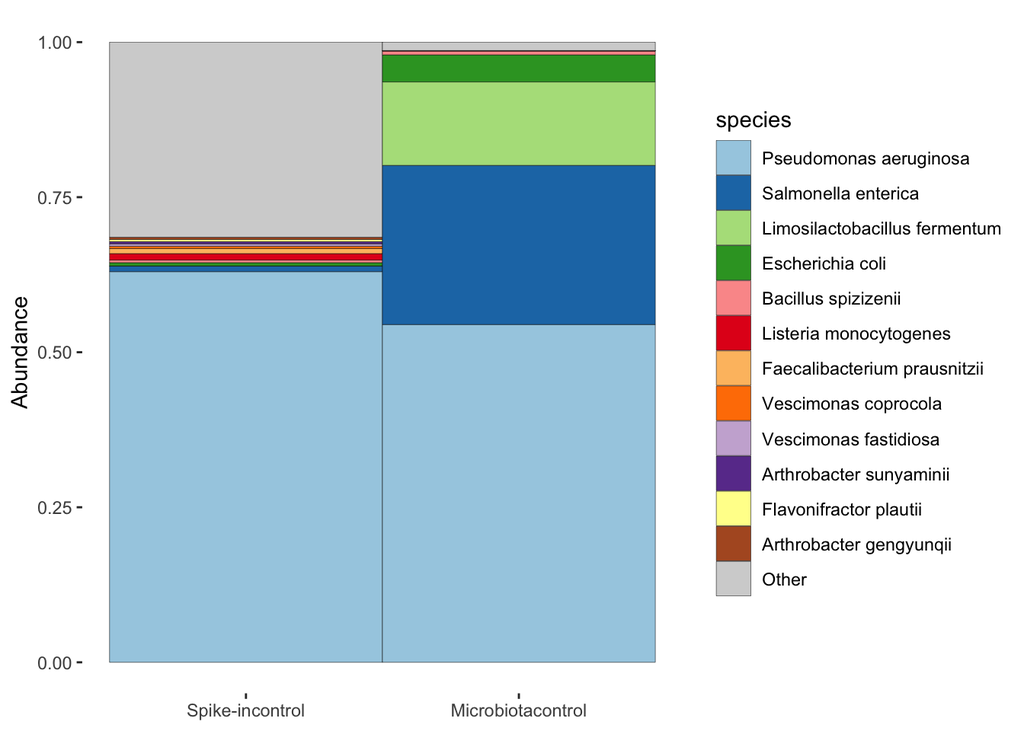

```r
control_ps %>%
  comp_barplot(tax_level = "species", n_taxa = 12)
```

```r
control_ps %>%
  subset_samples(sample_names(control_ps) == "Microbiotacontrol") %>%
  tax_transform("compositional") %>%
  psmelt() %>%
  select(OTU, Sample, Abundance, species) %>%
  rename(taxid = OTU) %>%
  slice(1:10)
```

```
##      taxid            Sample    Abundance                       species
## 1      287 Microbiotacontrol 0.5446379814        Pseudomonas aeruginosa
## 2    28901 Microbiotacontrol 0.2566809331           Salmonella enterica
## 3     1613 Microbiotacontrol 0.1344197490 Limosilactobacillus fermentum
## 4      562 Microbiotacontrol 0.0437512739              Escherichia coli
## 5    96241 Microbiotacontrol 0.0058657999           Bacillus spizizenii
## 6     1351 Microbiotacontrol 0.0015128798         Enterococcus faecalis
## 7     1639 Microbiotacontrol 0.0010769619        Listeria monocytogenes
## 8      623 Microbiotacontrol 0.0009082005             Shigella flexneri
## 9  2774929 Microbiotacontrol 0.0006076493     Enterococcus sp. DIV2451a
## 10  380021 Microbiotacontrol 0.0005449906         Pseudomonas protegens
```

```r
# Bacillus spizizenii is a subspecies of Bacillus subtilis

# Numbers and species from ZymoBIOMICS Microbial Community Standard:
zymobiomics_species <- c("Pseudomonas aeruginosa",
                         "Escherichia coli",
                         "Salmonella enterica",
                         "Limosilactobacillus fermentum",
                         "Enterococcus faecalis",
                         "Staphylococcus aureus",
                         "Listeria monocytogenes",
                         "Bacillus subtilis",
                         "Saccharomyces cerevisiae",
                         "Cryptococcus neoformans")

control_ps %>%
  subset_samples(sample_names(control_ps) == "Microbiotacontrol") %>%
  tax_transform("compositional") %>%
  psmelt() %>%
  select(OTU, Sample, Abundance, species) %>%
  rename(taxid = OTU,
         `Observed relative abundance` = Abundance,
         Species = species) %>%
  filter(Species %in% zymobiomics_species) %>%
  mutate(Species = factor(Species, levels = zymobiomics_species),
         `Expected relative abundance` = case_when(Species %in% c("Pseudomonas aeruginosa",
                                                                  "Escherichia coli",
                                                                  "Salmonella enterica",
                                                                  "Limosilactobacillus fermentum",
                                                                  "Enterococcus faecalis",
                                                                  "Staphylococcus aureus",
                                                                  "Listeria monocytogenes",
                                                                  "Bacillus subtilis") ~ 12 / 100,
                                                   Species %in% c("Saccharomyces cerevisiae",
                                                                  "Cryptococcus neoformans") ~ 2 / 100),
         Difference = `Observed relative abundance` - `Expected relative abundance`,
         log2FC = log2(`Observed relative abundance` / `Expected relative abundance`)) %>%
  select(Species, `Observed relative abundance`, `Expected relative abundance`, Difference, log2FC) %>%
  arrange(Species)
```

```
##                          Species Observed relative abundance
## 1         Pseudomonas aeruginosa                5.446380e-01
## 2               Escherichia coli                4.375127e-02
## 3            Salmonella enterica                2.566809e-01
## 4  Limosilactobacillus fermentum                1.344197e-01
## 5          Enterococcus faecalis                1.512880e-03
## 6          Staphylococcus aureus                4.646605e-04
## 7         Listeria monocytogenes                1.076962e-03
## 8              Bacillus subtilis                4.474256e-05
## 9       Saccharomyces cerevisiae                1.169183e-04
## 10       Cryptococcus neoformans                3.382039e-05
##    Expected relative abundance  Difference      log2FC
## 1                         0.12  0.42463798   2.1822632
## 2                         0.12 -0.07624873  -1.4556375
## 3                         0.12  0.13668093   1.0969417
## 4                         0.12  0.01441975   0.1637107
## 5                         0.12 -0.11848712  -6.3095932
## 6                         0.12 -0.11953534  -8.0126417
## 7                         0.12 -0.11892304  -6.7999234
## 8                         0.12 -0.11995526 -11.3890989
## 9                         0.02 -0.01988308  -7.4183556
## 10                        0.02 -0.01996618  -9.2078908
```

## 4 Wrangling and plotting

Reading in the kraken-inspect file from the PlusPFP database, extracting and plotting the relative abundances of taxa Bacteria, Eukaryota, Archaea and Viruses. Also plotting relative abundances of the same taxa for all samples in the rarefied phyloseq object. Additionally plotting the relative abundances of the top 12 phyla from the rarefied phyloseq object. Combining into one plot. Finally calculating median relative abundances for both the top-level taxonomy rank and the phylum rank on the rarefied data.

```r
inspect <- read_table("inspect.txt",
                      comment = "#",
                      col_names = c("percent","kmers","taxa","rank","taxid","name"))

toptax_levels <- c("Bacteria", "Eukaryota", "Archaea", "Viruses")

plot_db <- inspect %>%
  filter(taxid %in% c(2, 2157, 2759, 10239)) %>%
  mutate(abundance = percent / 100,
         name = factor(name, levels = toptax_levels),
         stack_order = fct_reorder(name, abundance)) %>%
  ggplot(aes(x = "", y = abundance, fill = name, group = stack_order)) +
  geom_col(width = 0.2) +
  scale_x_discrete(expand = c(0, 0)) +
  scale_fill_brewer(palette = "Set3",
                    breaks = c("Bacteria", "Eukaryota", "Archaea", "Viruses")) +
  labs(title = "A) Top-level taxonomy (DB)",
       x = "",
       y = "Relative abundance") +
  theme_minimal() +
  theme(axis.ticks.x = element_blank(),
        panel.grid.major = element_blank(),
        panel.grid.minor = element_blank(),
        axis.text.x = element_text(angle = 90),,
        plot.title = element_text(hjust = 0.50),
        axis.ticks.y = element_line()) +
  guides(fill = guide_legend(title = "Top-level taxonomy"))


plot_toptax <- rarefied_ps %>%
  comp_barplot(tax_level = "top_rank") +
  theme(axis.text.x = element_text(angle = 90, vjust = 0.75, hjust = 1, margin = margin(t = -9)),
        axis.ticks.x = element_blank(),
        legend.position = "none",
        plot.title = element_text(hjust = 0.50)) +
        #legend.position = "inside",
        #legend.key.size = unit(0.9, "lines")) +
  labs(y = "",
       title = "B) Top-level taxonomy") +
  scale_fill_brewer(palette = "Set3",
                    breaks = toptax_levels)


plot_phyla <- rarefied_ps %>%
  comp_barplot(tax_level = "phylum",
               n_taxa = 12) +
  theme(axis.text.x = element_text(angle = 90, vjust = 0.75, hjust = 1, margin = margin(t = -9)),
        axis.ticks.x = element_blank(),
        plot.title = element_text(hjust = 0.50)) +
  labs(title = "C) Phylum",
       y = "") +
  guides(fill = guide_legend(title = "Phylum"))


plot_db + plot_toptax + plot_phyla +
  plot_layout(widths = c(0.40, 1.2, 1.35), guides = "collect") &
  theme(legend.title = element_text(size = 13),
        legend.text  = element_text(size = 9),
        legend.key.size = unit(0.9, "lines"),
        legend.key.height = unit(0.9, "lines"),
        legend.key.width  = unit(0.9, "lines"),
        legend.key = element_rect(color = "black", linewidth = 0.3),
        legend.background = element_blank())
```

[figure not shown]

```r
ggsave("abundance_comp.png", width = 12)


# top top_rank
rarefied_ps %>%
  tax_agg("top_rank") %>%
  tax_transform("compositional") %>%
  psmelt() %>%
  group_by(OTU) %>%
  summarise(median_RA = median(Abundance)*100) %>%
  arrange(desc(median_RA))
```

```
## # A tibble: 4 × 2
##   OTU       median_RA
##   <chr>         <dbl>
## 1 Bacteria    95.1
## 2 Eukaryota    4.25
## 3 Archaea      0.654
## 4 Viruses      0.0379
```

```r
# top phyla
rarefied_ps %>%
  tax_agg("phylum") %>%
  tax_transform("compositional") %>%
  psmelt() %>%
  group_by(OTU) %>%
  summarise(median_RA = median(Abundance)*100) %>%
  arrange(desc(median_RA))
```

```
## # A tibble: 98 × 2
##    OTU                     median_RA
##    <chr>                       <dbl>
##  1 Bacillota                  31.0
##  2 Actinomycetota             23.7
##  3 Pseudomonadota             20.7
##  4 Bacteroidota                8.94
##  5 Streptophyta                3.62
##  6 Thermodesulfobacteriota     1.33
##  7 Methanobacteriota           0.626
##  8 Planctomycetota             0.507
##  9 Myxococcota                 0.485
## 10 Verrucomicrobiota           0.431
## # ℹ 88 more rows
```

## 5 Statistics

Aggregating the rarefied phyloseq object to phylum rank, and transforming to relative abundances (“compositional”). Then filtering to only keep bacterial taxa, and filtering out phyla with a mean relative abundance below 1% across all samples. Then fitting an ANOVA with sample-level phylum relative abundance as response variable, and an interaction term with season * location * phylum (main effects and interactions) as explanatory variables. Then performing a TukeyHSD-test on the ANOVA, and extracting contrasts where the compared groups belong to the same phylum, and have p-values below 0.05.

```r
phylum_data <- rarefied_ps %>%
  tax_agg("phylum") %>%
  tax_transform("compositional") %>%
  psmelt() %>%
  #filter(Sample != "WKR24-79") %>%
  filter(top_rank == "Bacteria") %>%
  group_by(phylum) %>%
  mutate(mean_abundance = mean(Abundance)) %>%
  ungroup() %>%
  filter(mean_abundance > 0.01)

# ANOVA
## Note: Relative abundance is not independent, increase one phylums abundance -> decrease others (violates assumptions)
a <- aov(Abundance ~ season * location * phylum,
    data = phylum_data)

# Tukey HSD
Tukey <- TukeyHSD(a, conf.level = 0.95)

same_phylum <- Tukey$`season:location:phylum` %>%
  as.data.frame() %>%
  rownames_to_column() %>%
  separate_wider_delim(rowname,
                       delim = "-",
                       names = c("obs_1", "obs_2")) %>%
  separate_wider_delim(obs_1,
                       delim = ":",
                       names = c("season_1", "location_1", "phylum_1")) %>%
  separate_wider_delim(obs_2,
                       delim = ":",
                       names = c("season_2", "location_2", "phylum_2")) %>%
  filter(phylum_1 == phylum_2,
         `p adj` < 0.05)

same_phylum
```

```
## # A tibble: 4 × 10
##   season_1 location_1 phylum_1      season_2 location_2 phylum_2   diff      lwr
##   <chr>    <chr>      <chr>         <chr>    <chr>      <chr>     <dbl>    <dbl>
## 1 Summer   Røros      Actinomyceto… Autumn   Mo i Rana  Actinom…  0.233  0.00930
## 2 Winter   Røros      Actinomyceto… Autumn   Mo i Rana  Actinom…  0.266  0.0718
## 3 Winter   Røros      Actinomyceto… Winter   Mo i Rana  Actinom…  0.204  0.0106
## 4 Autumn   Tana       Actinomyceto… Winter   Røros      Actinom… -0.244 -0.430
## # ℹ 2 more variables: upr <dbl>, `p adj` <dbl>
```